# Лабораторная работа №9

Операционные системы - Бекауов А.Т

Российский университет дружбы народов, Москва, Россия

# Введение

## Цель работы

Цель данной лабораторной работы - освоение основных возможностей командной оболочки Midnight Commander. Приобретение навыков практической работы по просмотру каталогов и файлов; манипуляций с ними.

# Выполнение лабораторной работы

# Задания по mc

## Задание 1: man: mc

Первым делом изучаю информацию о mc, вызвав в командной строке man mc

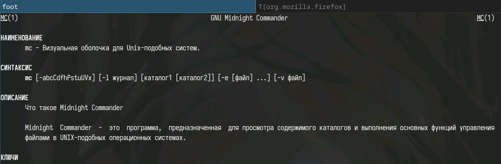

## Задание 2: Окно mc

Далее запускаю mc и изучаб его структуру и меню

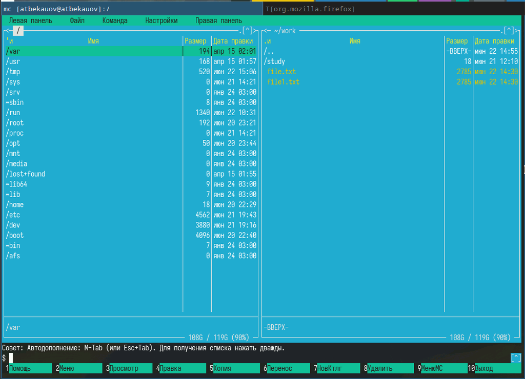

## Задание 2: Навигация

С помощью стрелок влево и вправо имею возможность двигаться вверх и вниз по директориям, клавиши вверх и вниз позволяют перебирать объекты в пределах выбранной директории

## Задание 3: Копирование

С помощью f5 могу копировать объекты из директории открытой в одном окне, в директорию второго окна

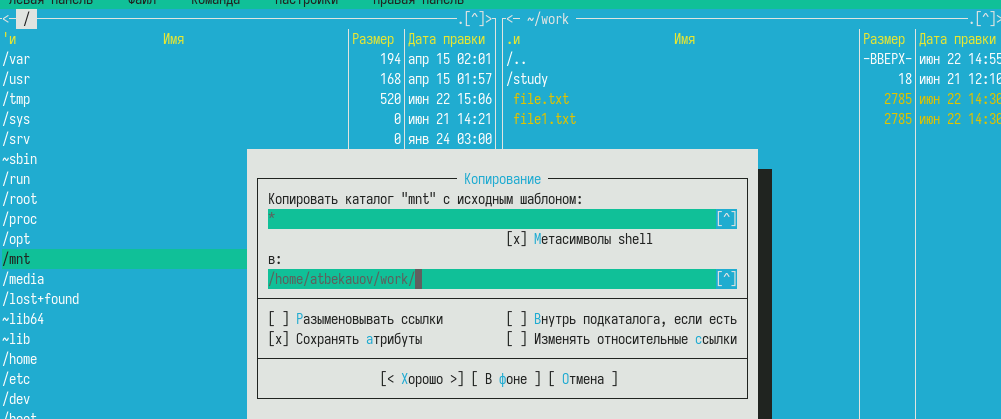

## Задание 3: Перемещение

С помощью f6 могу перемещать объекты из директории открытой в одном окне, в директорию второго окна

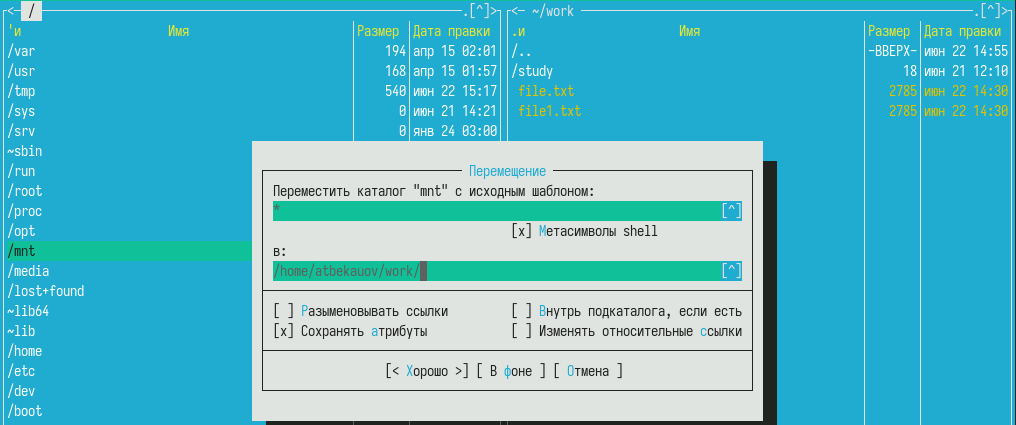

## Задание 4: Информация о файлах

Выбраю в падающем списке “левая/правая панель” пункт информация, выбранное окно теперь выводит информацию о файлах выделенны на втором окне.

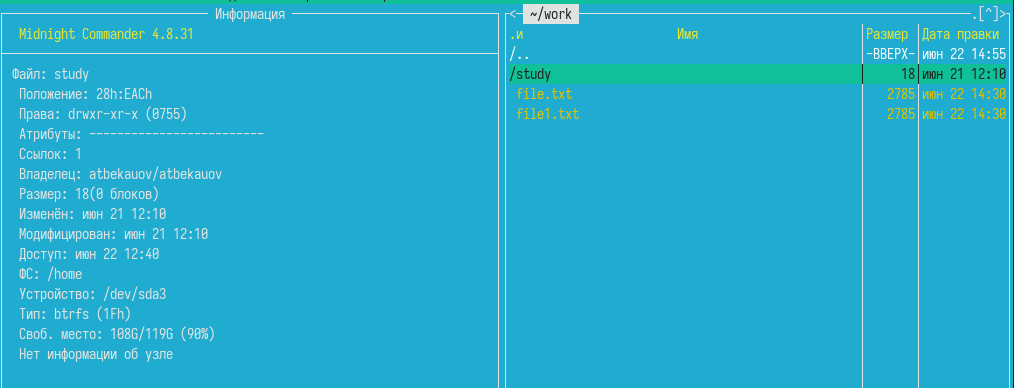

## Задание 5: Просмотр содержимого

Выбраю в падающем списке “Файл” пункт просмотр содержимого, окно mc теперь выводит содержимое выбранного файла

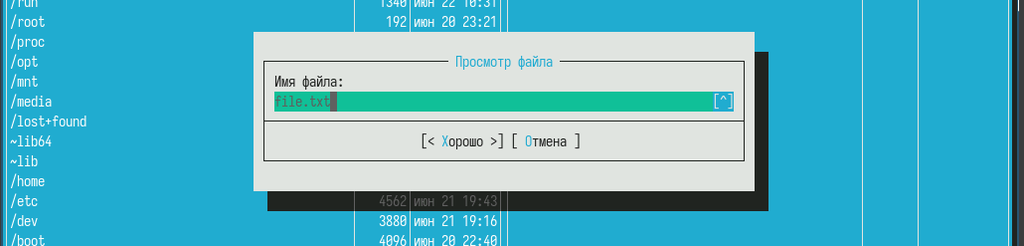

## Задание 5: Создание каталога

Выбраю в падающем списке “Файл” пункт создание каталога, mc теперь выводит окно, в которое нужно ввести имя нового каталога.

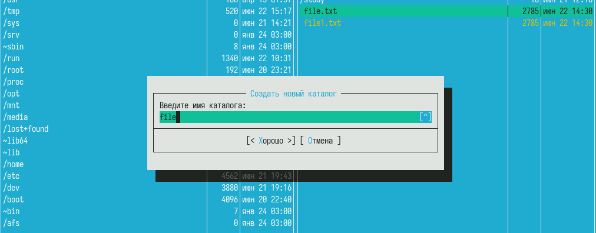

## Задание 6: Поиск файла

Далее в падающем списке “Команда” выбираю пункт поиск файла, ввожу поиск по ~, с параметрами: имя “*.cpp” , содержание “main”. Найден файл cpp подготовленный мной в ходе лабораторной

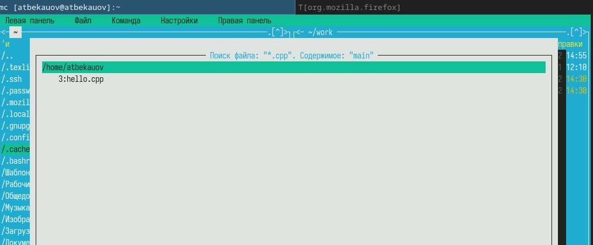

#Задание по встроенному редактору mc

## Задание 1 и 2

Создал текстовый файл text.txt, открою его с помощью встроенного в mc редактора (f4)

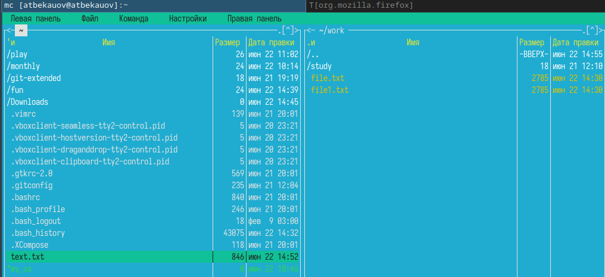

## Задание 3: text.txt в mcedit

Вставил в Файл text.txt случайный текст.

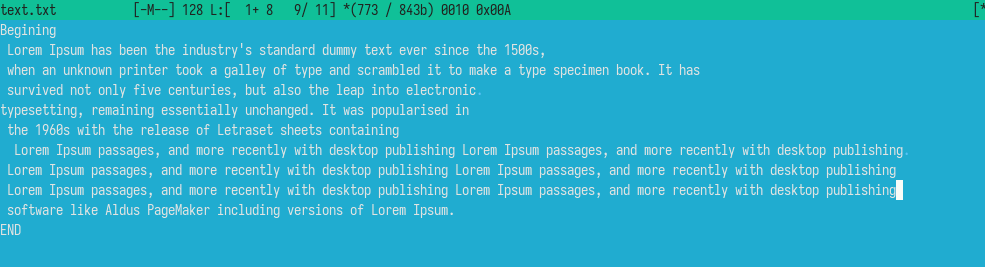

## Задание 4: удаление строки

С помощью комбинации клавиш Ctrl+y удалю первую строку текста

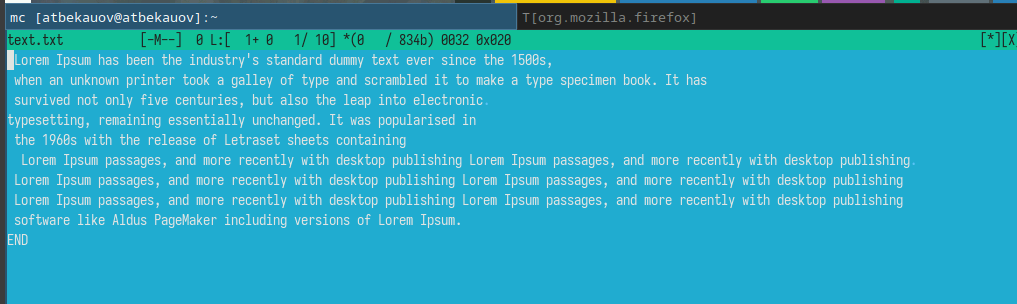

## Задание 4: копирование фрагмента

Выделяю последнюю строчку текста и с помощью кнопки f5 копирую её.

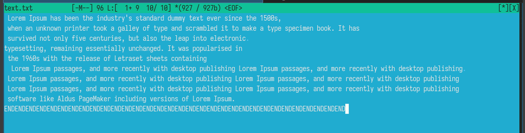

## Задание 4: перемещение фрагмента

Выделяю последнюю строчку текста и с помощью кнопки f6 перемещаю её.

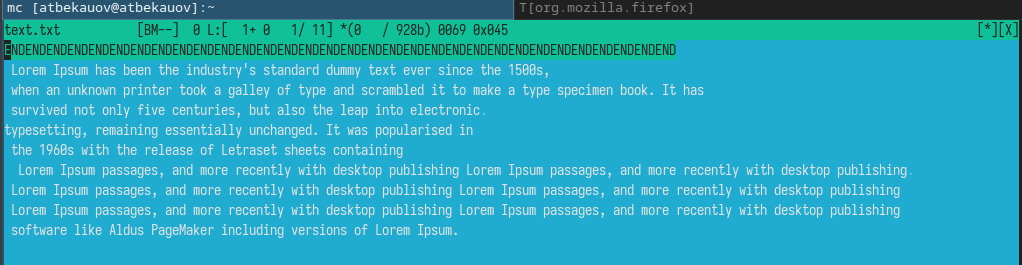

## Задание 4: сохранение файла

С помощью клавиши f2 сохраняю файл.

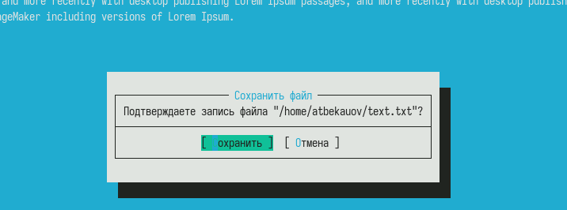

## Задание 4: Остальные действия

В начало и конец текста можно перемещаться с помощью клавиш PG UP и PG DN. С помощью комбиинации Ctrl+u можно отменять последнее действие. Сохроняю и закрываю файл с помощью кнопки f10.

##Задание 5 и 6: Подсветка синтаксиса

Открою файл программы на с++, в mcedit. Вижу, что синтаксис файла подсвечен.

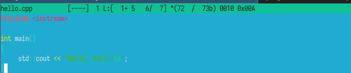

# Заключение

## Выводы

В ходе данной лабораторной работы я освоил основные возможности командной оболочки Midnight Commander. Приобрёл навыки практической работы по просмотру каталогов и файлов; манипуляций с ними.